# Introduction

The film industry has a massive impact on the lives of many, influencing audiences through storytelling and generating substantial economic benefits, including ticket sales, merchandise, and employment. Given the industry's significance, understanding the factors that contribute to a successful movie is imperative.

This analysis aims to answer the questions: **What variables impact the profit generated by a film and can profit be predicted using these variables?**

The working hypothesis posits that the average IMDB rating, budget, runtime, primary genre, and the film's target audience (specifically, whether it targets adults) have a significant correlation with the profit generated.

# Dataset

The working dataset, sourced from Kaggle, consists of film entries from IMDB, containing **1,072,255 entries** with **42 features**. To simplify the analysis and develop a more robust model, this study will focus on a selected subset of features.

### Features included in this analysis:

- **vote_average**: Average IMDB Rating, indicating the film's overall reception.
- **budget**: The financial resources allocated for the film's production.
- **runtime**: Length of the film in minutes, which may influence viewer engagement.
- **adult**: A boolean value (True or False) indicating whether the film targets an adult audience.
- **genre**: The primary genre of the film, determined by the first entry in the genres_list feature.

```python
# import libraries
import pandas as pd
import numpy as np
import matplotlib.pyplot as plt
import seaborn as sns
import ast
from matplotlib.gridspec import GridSpec
from sklearn.model_selection import train_test_split
import statsmodels.api as sm
from sklearn.metrics import mean_squared_error, mean_absolute_error, r2_score
from sklearn.ensemble import RandomForestRegressor
import tensorflow as tf
from tensorflow.keras.models import Sequential
from tensorflow.keras.layers import Dense
from sklearn.preprocessing import MinMaxScaler
```

```python
# import and view dataset
df = pd.read_csv('datasets/movies.csv')
df.head(3)
```

|  | id | title | vote_average | vote_count | status | release_date | revenue | runtime | adult | backdrop_path | ... | Star3 | Star4 | Writer | Director_of_Photography | Producers | Music_Composer | genres_list | Cast_list | overview_sentiment | all_combined_keywords |
| --- | --- | --- | --- | --- | --- | --- | --- | --- | --- | --- | --- | --- | --- | --- | --- | --- | --- | --- | --- | --- | --- |
| 0 | 27205 | Inception | 8.364 | 34495 | Released | 2010-07-15 | 825532764 | 148 | False | /8ZTVqvKDQ8emSGUEMjsS4yHAwrp.jpg | ... | Elliot Page | Ken Watanabe | Christopher Nolan | Wally Pfister | Thomas Tull, Christopher Nolan, Chris Brigham,... | Hans Zimmer | ['Action', 'Science Fiction', 'Adventure'] | ['Tim Kelleher', 'Silvie Laguna', 'Natasha Bea... | -0.011111 | ['s', 'philosophy', 'skilled', 'kidnapping', '... |
| 1 | 157336 | Interstellar | 8.417 | 32571 | Released | 2014-11-05 | 701729206 | 169 | False | /pbrkL804c8yAv3zBZR4QPEafpAR.jpg | ... | Jessica Chastain | Mackenzie Foy | Jonathan Nolan | Hoyte van Hoytema | Jake Myers, Emma Thomas, Jordan Goldberg, Thom... | Hans Zimmer | ['Adventure', 'Drama', 'Science Fiction'] | ['Jeff Hephner', 'William Devane', 'Elyes Gabe... | 0.045455 | ['thoughtful', 'use', 'scientist', 'quantum me... |
| 2 | 155 | The Dark Knight | 8.512 | 30619 | Released | 2008-07-16 | 1004558444 | 152 | False | /nMKdUUepR0i5zn0y1T4CsSB5chy.jpg | ... | Aaron Eckhart | Michael Caine | Jonathan Nolan | Wally Pfister | Kevin De La Noy, Thomas Tull, Christopher Nola... | Hans Zimmer, James Newton Howard | ['Drama', 'Action', 'Crime', 'Thriller'] | ['Tommy Lister Jr.', 'Edison Chen', 'Beatrice ... | 0.025000 | ['reign', 'harvey', 'proves', 'partnership', '... |

3 rows × 42 columns

```python
# display size of dataset
df.shape
```

```
(1072255, 42)
```

```python
# display features and respective data types
df.dtypes
```

```
id                           int64
title                       object
vote_average               float64
vote_count                   int64
status                      object
release_date                object
revenue                      int64
runtime                      int64
adult                         bool
backdrop_path               object
budget                       int64
homepage                    object
imdb_id                     object
original_language           object
original_title              object
overview                    object
popularity                 float64
poster_path                 object
tagline                     object
production_companies        object
production_countries        object
spoken_languages            object
keywords                    object
release_year               float64
Director                    object
AverageRating              float64
Poster_Link                 object
Certificate                 object
IMDB_Rating                float64
Meta_score                 float64
Star1                       object
Star2                       object
Star3                       object
Star4                       object
Writer                      object
Director_of_Photography     object
Producers                   object
Music_Composer              object
genres_list                 object
Cast_list                   object
overview_sentiment         float64
all_combined_keywords       object
dtype: object
```

# Preprocessing

These preprocessing steps were crucial for preparing the dataset for subsequent analysis, ensuring the data was both relevant and representative.

```python
# Convert each entry in genres_list to a list
df['genres_list'] = df['genres_list'].apply(lambda x: ast.literal_eval(x))
```

```python
# create primary genre variable
df['genre'] = df['genres_list'].apply(lambda x: x[0] if len(x) > 0 else None)
print(df['genre'].head(3))
```

```
0       Action
1    Adventure
2        Drama
Name: genre, dtype: object
```

```python
df['profit'] = df['revenue'] - df['budget']
```

```python
# subset dataset to consist only of variables of interest
df = df[['profit', 'budget', 'vote_average', 'runtime', 'adult', 'genre']]
```

```python
df.describe()
```

|  | profit | budget | vote_average | runtime |
| --- | --- | --- | --- | --- |
| count | 1.072255e+06 | 1.072255e+06 | 1.072255e+06 | 1.072255e+06 |
| mean | 4.383944e+05 | 2.797329e+05 | 1.979590e+00 | 4.918518e+01 |
| std | 1.517492e+07 | 5.067542e+06 | 3.063890e+00 | 6.204454e+01 |
| min | -9.000000e+08 | 0.000000e+00 | 0.000000e+00 | -2.800000e+01 |
| 25% | 0.000000e+00 | 0.000000e+00 | 0.000000e+00 | 0.000000e+00 |
| 50% | 0.000000e+00 | 0.000000e+00 | 0.000000e+00 | 2.600000e+01 |
| 75% | 0.000000e+00 | 0.000000e+00 | 5.000000e+00 | 9.000000e+01 |
| max | 2.780000e+09 | 9.000000e+08 | 1.000000e+01 | 1.440000e+04 |

```python
# drop entries that have a 0 value for quantitative variables
columns = ['budget', 'profit', 'vote_average', 'runtime']
for column in columns: df = df[df[column] != 0]
```

```python
df.describe()
```

|  | profit | budget | vote_average | runtime |
| --- | --- | --- | --- | --- |
| count | 2.514700e+04 | 2.514700e+04 | 25147.000000 | 25147.000000 |
| mean | 1.596143e+07 | 1.083554e+07 | 6.341159 | 86.868334 |
| std | 8.777793e+07 | 2.692382e+07 | 1.865759 | 43.261078 |
| min | -1.995460e+08 | 1.000000e+00 | 0.500000 | 1.000000 |
| 25% | -1.500000e+06 | 2.000000e+04 | 5.333000 | 77.000000 |
| 50% | -2.000000e+04 | 1.000000e+06 | 6.297000 | 93.000000 |
| 75% | 5.068850e+04 | 8.500000e+06 | 7.200000 | 108.000000 |
| max | 2.750000e+09 | 4.600000e+08 | 10.000000 | 999.000000 |

```python
# assess null values
df.isna().sum()
```

```
profit          0
budget          0
vote_average    0
runtime         0
adult           0
genre           0
dtype: int64
```

```python
# assess genre values
df['genre'].unique()
```

```
array(['Action', 'Adventure', 'Drama', 'Science Fiction', 'Thriller',
       'Comedy', 'Crime', 'Animation', 'Fantasy', 'Horror', 'Family',
       'Mystery', 'Western', 'History', 'Music', 'War', 'Romance',
       'Documentary', 'TV Movie', 'Unknown'], dtype=object)
```

```python
# replace genre 'Unknown' values with nulls and display count
df['genre'] = df['genre'].replace('Unknown', None)
df['genre'].isna().sum()
```

```
873
```

```python
# drop null values in genre
df.dropna(inplace=True)
df.isna().sum()
```

```
profit          0
budget          0
vote_average    0
runtime         0
adult           0
genre           0
dtype: int64
```

```python
# view subsetted df
df.head(3)
```

|  | profit | budget | vote_average | runtime | adult | genre |
| --- | --- | --- | --- | --- | --- | --- |
| 0 | 665532764 | 160000000 | 8.364 | 148 | False | Action |
| 1 | 536729206 | 165000000 | 8.417 | 169 | False | Adventure |
| 2 | 819558444 | 185000000 | 8.512 | 152 | False | Drama |

# Data Understanding/Visualization

## Quantitative Variables

```python
# function to create boxplots of quantitative variables
def boxplotVisualize(df):
    # Visualize quantitative variable distributions
    fig , ax = plt.subplots(nrows=2, ncols=4, figsize=(22, 10))
    fig.suptitle('Quantitative Data Visualizations', fontsize=22)

    columns = ['profit', 'budget', 'vote_average', 'runtime']

    for i in range(4):
        df.boxplot(column=columns[i], ax=ax[0,i])
        sns.histplot(df[columns[i]], kde=True, ax=ax[1, i])

    plt.show()
```

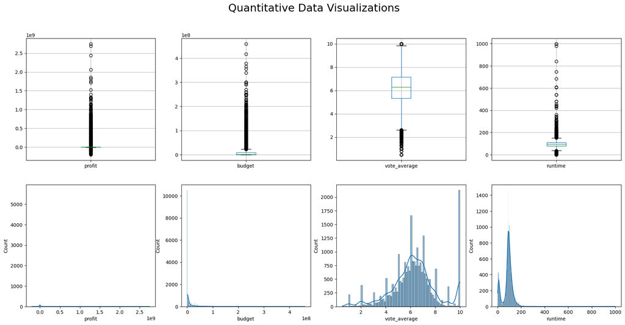

```python
boxplotVisualize(df)
```

```python
#Function to remove outliers based on IQR
def removeOutliersIQR(df, column):

    q1 = np.percentile(df[column], 25)
    q3 = np.percentile(df[column], 75)

    iqr = q3 - q1
    upperThreshold = q3 + (1.5 * iqr)
    lowerThreshold = q1 - (1.5 * iqr)

    df = df[(df[column] <= upperThreshold) & (df[column] >= lowerThreshold)]

    return df
```

```python
# remove outliers and display descriptive statistics
while True:
    shape = df.shape
    df = removeOutliersIQR(df, 'runtime')
    df = removeOutliersIQR(df, 'vote_average')
    df = removeOutliersIQR(df, 'budget')
    df = removeOutliersIQR(df, 'profit')
    if (df.shape == shape): break
df.describe()
```

|  | profit | budget | vote_average | runtime |
| --- | --- | --- | --- | --- |
| count | 7.141000e+03 | 7.141000e+03 | 7141.000000 | 7141.000000 |
| mean | -4.729537e+05 | 5.786278e+05 | 5.705284 | 90.831956 |
| std | 6.822571e+05 | 6.522445e+05 | 1.376348 | 12.894554 |
| min | -2.311727e+06 | 1.000000e+00 | 2.643000 | 60.000000 |
| 25% | -9.376180e+05 | 3.300000e+04 | 4.800000 | 83.000000 |
| 50% | -2.000000e+05 | 3.000000e+05 | 5.800000 | 90.000000 |
| 75% | -1.150000e+04 | 1.000000e+06 | 6.700000 | 99.000000 |
| max | 1.374000e+06 | 2.400005e+06 | 9.200000 | 123.000000 |

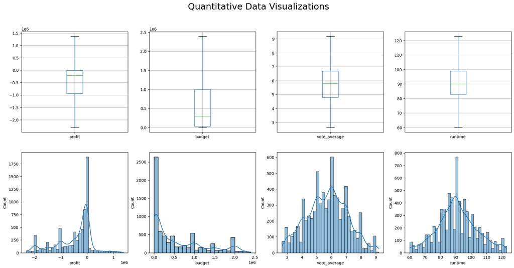

```python
# visualize transformed quantitative variables
boxplotVisualize(df)
```

```python
df.shape
```

```
(7141, 6)
```

# Categorical Variaables

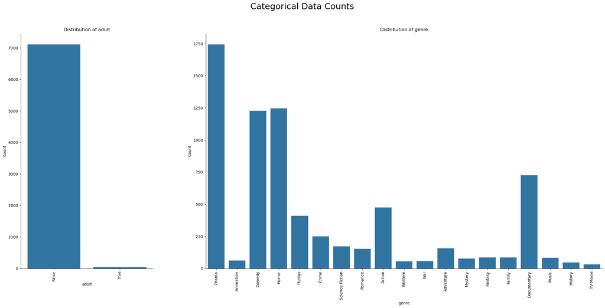

```python
# Create catagorical visualizations
fig = plt.figure(figsize=(27, 11)) # set figsize
gs = GridSpec(1, 2, width_ratios=[1, 3]) # set number and resize subplots
ax = [fig.add_subplot(gs[0]), fig.add_subplot(gs[1])]  # fits GridSpec to subplots
fig.suptitle('Categorical Data Counts', fontsize=22) # add title
# Variables to be visualized
columns = ['adult', 'genre']
# create and format countplots
for i in range(2):
    sns.countplot(x=columns[i], data=df, ax=ax[i]); ax[i].set_title('Distribution of ' + columns[i])
    ax[i].set_ylabel('Count'); ax[i].set_xlabel(columns[i])
    ax[i].tick_params(axis='x', rotation=90)
    ax[i].spines['top'].set_visible(False); ax[i].spines['right'].set_visible(False)
plt.subplots_adjust(hspace=.8)
plt.show()
```

```python
# display adult count
df['adult'].sum()
```

```
38
```

```python
# display genre counts
df['genre'].value_counts()
```

```
genre
Drama              1743
Horror             1246
Comedy             1227
Documentary         726
Action              474
Thriller            410
Crime               250
Science Fiction     173
Adventure           157
Romance             152
Fantasy              86
Family               85
Music                83
Mystery              76
Animation            62
War                  58
Western              56
History              46
TV Movie             31
Name: count, dtype: int64
```

```python
# Drop genre with little representation
df = df[df['genre'] != 'TV Movie']
```

```python
# sample each genre to consist of 31 entries
sampled_df = df.groupby('genre').apply(lambda x: x.sample(n=31, random_state=42), include_groups=True)
```

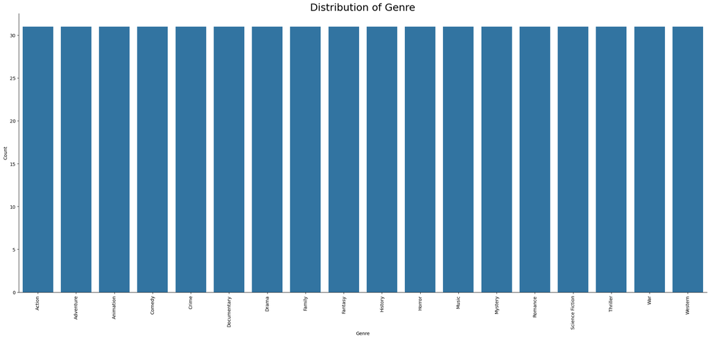

```python
# Create a countplot for transformed genre
fig, ax = plt.subplots(figsize=(27, 11))
sns.countplot(x='genre', data=sampled_df, ax=ax)

ax.set_title('Distribution of Genre', fontsize='22'); ax.set_ylabel('Count'); ax.set_xlabel('Genre')
ax.tick_params(axis='x', rotation=90)
ax.spines['top'].set_visible(False); ax.spines['right'].set_visible(False)

plt.show()
```

```python
# get dummy representation for genres
sampled_df = pd.get_dummies(sampled_df, columns=['genre'], dtype='int', prefix='genre')
sampled_df.columns
```

```
Index(['profit', 'budget', 'vote_average', 'runtime', 'adult', 'genre_Action',
       'genre_Adventure', 'genre_Animation', 'genre_Comedy', 'genre_Crime',
       'genre_Documentary', 'genre_Drama', 'genre_Family', 'genre_Fantasy',
       'genre_History', 'genre_Horror', 'genre_Music', 'genre_Mystery',
       'genre_Romance', 'genre_Science Fiction', 'genre_Thriller', 'genre_War',
       'genre_Western'],
      dtype='object')
```

```python
sampled_df.head()
```

| genre |  | profit | budget | vote_average | runtime | adult | genre_Action | genre_Adventure | genre_Animation | genre_Comedy | genre_Crime | ... | genre_Fantasy | genre_History | genre_Horror | genre_Music | genre_Mystery | genre_Romance | genre_Science Fiction | genre_Thriller | genre_War | genre_Western |
| --- | --- | --- | --- | --- | --- | --- | --- | --- | --- | --- | --- | --- | --- | --- | --- | --- | --- | --- | --- | --- | --- | --- |
| Action | 266408 | -35000 | 35000 | 7.000 | 87 | False | 1 | 0 | 0 | 0 | 0 | ... | 0 | 0 | 0 | 0 | 0 | 0 | 0 | 0 | 0 | 0 |
|  | 269432 | 7678 | 6654 | 8.000 | 81 | False | 1 | 0 | 0 | 0 | 0 | ... | 0 | 0 | 0 | 0 | 0 | 0 | 0 | 0 | 0 | 0 |
|  | 8549 | -1500000 | 1500000 | 7.000 | 113 | False | 1 | 0 | 0 | 0 | 0 | ... | 0 | 0 | 0 | 0 | 0 | 0 | 0 | 0 | 0 | 0 |
|  | 326816 | -1146442 | 1183424 | 8.000 | 98 | False | 1 | 0 | 0 | 0 | 0 | ... | 0 | 0 | 0 | 0 | 0 | 0 | 0 | 0 | 0 | 0 |
|  | 14348 | -1500000 | 1500000 | 4.414 | 90 | False | 1 | 0 | 0 | 0 | 0 | ... | 0 | 0 | 0 | 0 | 0 | 0 | 0 | 0 | 0 | 0 |

5 rows × 23 columns

# Data Understainding/Visualization

## Scatterplots with Regression Line

To understand the relationship between the profit generated and the quantitative variables, scatter plots were created with the independent variables plotted on the x-axis and profit (the dependent variable) on the y-axis. A regression line was included in each plot to illustrate the nature of the relationship.

The analysis revealed that:

- The only variable demonstrating a clear relationship with profit was budget.
- This suggests that as the budget increases, profit tends to decrease, indicating a negative correlation.

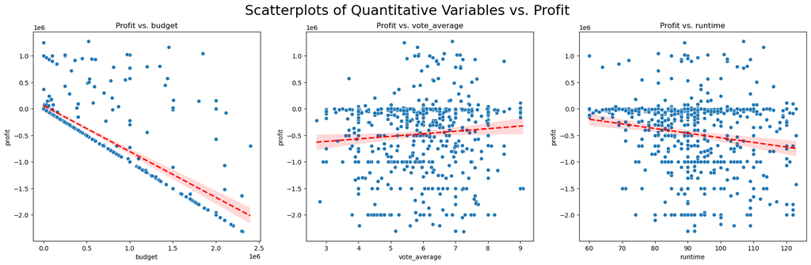

```python
# columns to be visualized
columns = ['budget', 'vote_average', 'runtime']

fig, axes = plt.subplots(nrows=1, ncols=3, figsize=(22, 6)) #set number of plots and figsize
fig.suptitle('Scatterplots of Quantitative Variables vs. Profit', fontsize=22) # set super title

# Create and format scatterplots with line of best fit
for i in range(3):
    sns.scatterplot(x=columns[i], y='profit', data=sampled_df, ax=axes[i])
    sns.regplot(x=columns[i], y='profit', data=sampled_df, ax=axes[i], scatter=False, color='red', line_kws={'linestyle':'--'})
    axes[i].set_title(f'Profit vs. {columns[i]}')
    axes[i].set_xlabel(columns[i]); axes[i].set_ylabel('profit')
plt.show()
```

## Correlation Matrix

The correlation martix below was created to verify the relationships between quantitative variables. The key findings include:

- **Budget and Profit:**
  - Correlation Coefficient: **-0.8**
  - Interpretation: This indicates a strong negative linear relationship, suggesting that as the budget increases, profit tends to decrease significantly.
- **Vote Average:**
  - Correlation Coefficient: **0.089**
  - Interpretation: This illustrates an extremely weak positive linear relationship, indicating that vote average has minimal impact on profit.
- **Runtime:**
  - Correlation Coefficient: **-0.17**
  - Interpretation: This indicates a weak negative linear relationship, suggesting that runtime has a slight effect on profit, but the correlation is not strong.

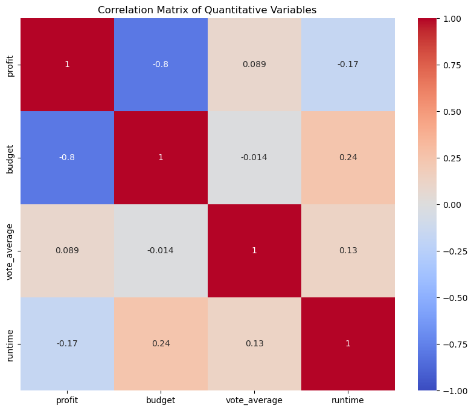

```python
# variables to be included in correlation matrix
quantitative_df  = sampled_df[['profit', 'budget', 'vote_average', 'runtime']]

corr_matrix = quantitative_df.corr() # create correlation matrix
plt.figure(figsize=(10,8))

sns.heatmap(corr_matrix, annot=True, cmap='coolwarm', vmin=-1) # create and format heatmap

plt.title('Correlation Matrix of Quantitative Variables') # set title
plt.show()
```

## Boxplots of Profit Distribution by Genre

To explore the relationship between genres and profit, the dataset was transformed, and a visualization consisting of boxplots for each genre was created. The analysis includes the following key points:

- **Median Profit Calculation**:
  - The median profit value was calculated for each genre, providing a clear indicator of the central tendency of profit within each genre.
- **Boxplot Visualization**:
  - The genres were plotted in ascending order based on their median profit values, allowing for easy comparison of profit distributions across genres.
- **Key Findings**:
  - **Top 3 Profit-Producing Genres** (ordered by median profit):
    1. **Crime**
    2. **Music**
    3. **Adventure**
  - **Bottom 3 Profit-Producing Genres** (ordered by median profit):
    1. **Thriller**
    2. **Western**
    3. **History**

This analysis highlights the positive relationship between genre and profit when ordered by median profit, indicating that certain genres tend to generate higher profits than others.

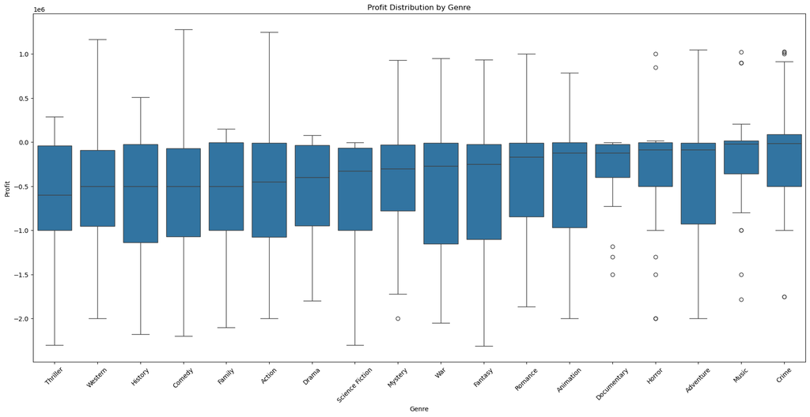

```python
# convert df to long format in order to map genres individually
df_long = pd.melt(sampled_df, var_name='genre', value_name='has_genre',
                  value_vars=[col for col in sampled_df.columns if col.startswith('genre_')])

# subset for rows where the genre is present
df_long = df_long[df_long['has_genre'] == 1]
# add revenue to df_long
df_long['profit'] = sampled_df['profit'].values
# remove genre_ prefix
df_long['genre'] = df_long['genre'].str.replace('genre_', '')
# Order genres by median revenue
median_revenue = df_long.groupby('genre')['profit'].median().sort_values()

# Create and format boxplots of genres ordered by median revenue
plt.figure(figsize=(22, 10))
sns.boxplot(x='genre', y='profit', data=df_long, order=median_revenue.index)

plt.title('Profit Distribution by Genre')
plt.xlabel('Genre')
plt.ylabel('Profit')
plt.xticks(rotation=45)
plt.show()
```

# Experiment 1: Multivariate Linear Regression

The first model is created using ordinary least squares regression. This process fits a linear equation to the training dataset that minimizes the squared residuals, or the difference between the predicted values and actual values. In this application, a constant is required to be included in the equation. This iteration will include all the variables of interest.

Firstly, the dataset is split into **X** and **y**, with **X** containing the predictor variables and **y** being the target variable **profit**. Then the data is normalized to a range of -1 to 1. This normalization process ensures that all features contribute equally to the distance calculations, improving the convergence of the regression algorithm and enhancing model performance.

**X** and **y** are further split into testing and training sets to train and evaluate the model using unseen data. The constant was initialized for both predictor subsets. The training data was passed to the statsmodels OLS function to calculate and return the multivariate linear regression model.

```python
X = sampled_df.drop(columns=['profit', 'adult'], axis=1)
y = sampled_df['profit']
```

```python
scaler = MinMaxScaler(feature_range=(-1, 1))

X_scaled = scaler.fit_transform(X)
X = pd.DataFrame(X_scaled, columns=X.columns)

y = scaler.fit_transform(y.values.reshape(-1, 1))
```

```python
# split datasets into training and testing sets
X_train, X_test, y_train, y_test = train_test_split(X, y, test_size=0.3, random_state=42)
```

```python
# Add constant
X_train = sm.add_constant(X_train)
X_test = sm.add_constant(X_test)
```

```python
lm1 = sm.OLS(y_train, X_train).fit()
lm1.summary()
```

OLS Regression Results

| Dep. Variable: | y | R-squared: | 0.682 |
| --- | --- | --- | --- |
| Model: | OLS | Adj. R-squared: | 0.665 |
| Method: | Least Squares | F-statistic: | 39.59 |
| Date: | Fri, 01 Nov 2024 | Prob (F-statistic): | 4.22e-79 |
| Time: | 15:13:15 | Log-Likelihood: | 41.568 |
| No. Observations: | 390 | AIC: | -41.14 |
| Df Residuals: | 369 | BIC: | 42.15 |
| Df Model: | 20 |  |  |
| Covariance Type: | nonrobust |  |  |

|  | coef | std err | t | P>\|t\| | [0.025 | 0.975] |
| --- | --- | --- | --- | --- | --- | --- |
| const | -0.0174 | 0.001 | -15.706 | 0.000 | -0.020 | -0.015 |
| budget | -0.5871 | 0.023 | -25.995 | 0.000 | -0.631 | -0.543 |
| vote_average | 0.0625 | 0.031 | 2.017 | 0.044 | 0.002 | 0.123 |
| runtime | 0.0086 | 0.028 | 0.310 | 0.757 | -0.046 | 0.063 |
| genre_Action | -0.0036 | 0.024 | -0.149 | 0.882 | -0.052 | 0.044 |
| genre_Adventure | 0.0831 | 0.022 | 3.857 | 0.000 | 0.041 | 0.126 |
| genre_Animation | 0.0400 | 0.031 | 1.275 | 0.203 | -0.022 | 0.102 |
| genre_Comedy | 0.0117 | 0.022 | 0.539 | 0.590 | -0.031 | 0.054 |
| genre_Crime | 0.0982 | 0.024 | 4.031 | 0.000 | 0.050 | 0.146 |
| genre_Documentary | -0.0156 | 0.025 | -0.634 | 0.526 | -0.064 | 0.033 |
| genre_Drama | -0.0205 | 0.022 | -0.915 | 0.361 | -0.064 | 0.024 |
| genre_Family | -0.0177 | 0.025 | -0.712 | 0.477 | -0.067 | 0.031 |
| genre_Fantasy | 0.0002 | 0.023 | 0.007 | 0.994 | -0.046 | 0.046 |
| genre_History | -0.0155 | 0.022 | -0.698 | 0.486 | -0.059 | 0.028 |
| genre_Horror | 0.0349 | 0.024 | 1.475 | 0.141 | -0.012 | 0.082 |
| genre_Music | 0.0420 | 0.023 | 1.848 | 0.065 | -0.003 | 0.087 |
| genre_Mystery | -0.0105 | 0.027 | -0.390 | 0.697 | -0.064 | 0.043 |
| genre_Romance | 0.0432 | 0.022 | 1.921 | 0.056 | -0.001 | 0.087 |
| genre_Science Fiction | -0.0104 | 0.023 | -0.456 | 0.649 | -0.055 | 0.034 |
| genre_Thriller | -0.0145 | 0.024 | -0.590 | 0.555 | -0.063 | 0.034 |
| genre_War | -0.0035 | 0.024 | -0.143 | 0.886 | -0.051 | 0.044 |
| genre_Western | 0.0375 | 0.023 | 1.607 | 0.109 | -0.008 | 0.083 |

| Omnibus: | 245.198 | Durbin-Watson: | 2.009 |
| --- | --- | --- | --- |
| Prob(Omnibus): | 0.000 | Jarque-Bera (JB): | 1736.179 |
| Skew: | 2.729 | Prob(JB): | 0.00 |
| Kurtosis: | 11.778 | Cond. No. | 3.67e+15 |

Notes:  
[1] Standard Errors assume that the covariance matrix of the errors is correctly specified.  
[2] The smallest eigenvalue is 4.5e-28. This might indicate that there are  
strong multicollinearity problems or that the design matrix is singular.

## P-Value Elimination

The following function eliminates the variable with the highest p-value above (.05) until all variables have a p-value below (.05). This is a commonly used threshold to evaluate the significance of variables meaning variables with a p-value above the threshold are insignificant and do not effectively capture a relationship with the target variable.

- budget
- genre_Adventure
- genre_Crime
- genre_Music
- genre_Romance

```python
def pValueElimination(X_train, y_train):
    while True:
        lm = sm.OLS(y_train, X_train).fit()
        p_vals = lm.pvalues

        max_val = p_vals.max()
        var_name = p_vals.idxmax()

        if max_val > .05: X_train = X_train.drop(columns=[var_name])
        else: break
    return lm

lm1 = pValueElimination(X_train, y_train)
```

```python
lm1.summary()
```

OLS Regression Results

| Dep. Variable: | y | R-squared (uncentered): | 0.677 |
| --- | --- | --- | --- |
| Model: | OLS | Adj. R-squared (uncentered): | 0.673 |
| Method: | Least Squares | F-statistic: | 161.5 |
| Date: | Fri, 01 Nov 2024 | Prob (F-statistic): | 3.56e-92 |
| Time: | 15:13:15 | Log-Likelihood: | 35.121 |
| No. Observations: | 390 | AIC: | -60.24 |
| Df Residuals: | 385 | BIC: | -40.41 |
| Df Model: | 5 |  |  |
| Covariance Type: | nonrobust |  |  |

|  | coef | std err | t | P>\|t\| | [0.025 | 0.975] |
| --- | --- | --- | --- | --- | --- | --- |
| budget | -0.5826 | 0.021 | -28.146 | 0.000 | -0.623 | -0.542 |
| genre_Adventure | 0.0845 | 0.020 | 4.292 | 0.000 | 0.046 | 0.123 |
| genre_Crime | 0.1023 | 0.021 | 4.776 | 0.000 | 0.060 | 0.144 |
| genre_Music | 0.0584 | 0.020 | 2.954 | 0.003 | 0.020 | 0.097 |
| genre_Romance | 0.0488 | 0.020 | 2.399 | 0.017 | 0.009 | 0.089 |

| Omnibus: | 253.680 | Durbin-Watson: | 2.015 |
| --- | --- | --- | --- |
| Prob(Omnibus): | 0.000 | Jarque-Bera (JB): | 1874.709 |
| Skew: | 2.837 | Prob(JB): | 0.00 |
| Kurtosis: | 12.120 | Cond. No. | 4.06 |

Notes:  
[1] R² is computed without centering (uncentered) since the model does not contain a constant.  
[2] Standard Errors assume that the covariance matrix of the errors is correctly specified.

# Evaluation

```python
X_test_LR = X_test[['budget', 'genre_Adventure', 'genre_Crime', 'genre_Music', 'genre_Romance']]
# predict test data
y_pred = lm1.predict(X_test_LR)
```

```python
r2 = r2_score(y_test, y_pred)
mse = mean_squared_error(y_test, y_pred)
mae = mean_absolute_error(y_test, y_pred)
rmse = np.sqrt(mse)

print(f"Linear Regression -  R^2: {r2:.3f}")
print(f"Linear Regression -  MSE: {mse:.3f}")
print(f"Linear Regression -  MAE: {mae:.3f}")
print(f"Linear Regression - RMSE: {rmse:.3f}")
```

```
Linear Regression -  R^2: 0.606
Linear Regression -  MSE: 0.068
Linear Regression -  MAE: 0.141
Linear Regression - RMSE: 0.261
```

### Model Performance Summary

- R² Value: The R² value of the final multivariate linear regression model is 0.606, indicating that the model explains 60.6% of the variance in the data concerning profit generated. This suggests a moderate level of explanatory power for the model.
- Mean Squared Error (MSE): The mean squared error, which represents the average of the squared residuals, is 0.068. This metric provides insight into the model's overall error magnitude.
- Root Mean Squared Error (RMSE): The root mean squared error is 0.261, providing a measure of the average error. This value suggests the typical size of the errors made by the model in predicting profit.
- Mean Absolute Error (MAE): The MAE is approximately 0.141, illustrating the average magnitude of the residuals without considering their direction, negative or positive.

# Experiment 2: Random Forest

In the second experiment, a Random Forest Regressor is employed to model the training data. This ensemble method consists of ten decision trees, which work together to improve predictive accuracy and robustness.

#### Hyperparameters:

- **Minimum Samples to Split:** Set to 2. This parameter dictates the minimum number of samples required to make a split in a decision tree. By keeping this value low, the model retains the ability to capture complex patterns in the data.
- **Minimum Samples per Leaf:** Also set to 2. This controls the minimum number of samples that must be present in a leaf node. Similar to the previous parameter, this helps prevent overfitting by ensuring that leaf nodes contain a sufficient number of observations.

These hyperparameters are strategically chosen to mitigate overfitting issues and reduce the complexity of the trees, allowing the random forest to generalize better to unseen data.

```python
rf = RandomForestRegressor(random_state=42, n_estimators=10, min_samples_split=2, min_samples_leaf=2).fit(X_train, y_train)
```

```python
pred_rf = rf.predict(X_test)
```

## Evaluation

```python
rf_r2 = r2_score(y_test, pred_rf)
rf_mse = mean_squared_error(y_test, pred_rf)
rf_mae = mean_absolute_error(y_test, pred_rf)
rf_rmse = np.sqrt(rf_mse)

print(f"Random Forest -  R^2: {rf_r2:.3f}")
print(f"Random Forest -  MSE: {rf_mse:.3f}")
print(f"Random Forest -  MAE: {rf_mae:.3f}")
print(f"Random Forest - RMSE: {rf_rmse:.3f}")
```

```
Random Forest -  R^2: 0.578
Random Forest -  MSE: 0.073
Random Forest -  MAE: 0.142
Random Forest - RMSE: 0.270
```

Based on the evaluation metrics presented, the Random Forest model performs slightly worse than the Multivariate Linear Regression model across all evaluation metrics. This decrease in performance, coupled with the increased complexity of the random forest, suggests that it may not be the most suitable model for evaluating the relationship between the predictor variables and the profit generated by a film.

Given the trade-off between model performance and complexity, the simpler multivariate linear regression model appears to provide a more effective framework for understanding the dynamics influencing film profitability.

# Experiment 3: Neural Network

In this experiment, a Neural Network is employed to model the relationship between the predictor variables and film profitability. The model architecture consists of:

- An input layer with 64 neurons utilizing the ReLU activation function, designed to capture complex patterns from the input features.
- A hidden layer with 32 neurons, also using ReLU activation to enhance learning capacity.
- An output layer with a single neuron, which produces the regression output without an activation function.

The model is compiled using the Adam optimizer and mean squared error (MSE) as the loss function, with mean absolute error (MAE) included as a metric for evaluation. Following the compilation, the model is trained on the provided training data.

```python
# Model Structure
model = Sequential([
    Dense(64, activation='relu', input_shape=(X_train.shape[1],)),  # Input layer with 64 neurons
    Dense(32, activation='relu'),  # Hidden layer with 32 neurons
    Dense(1)  # Output layer
])

model.compile(optimizer='adam', loss='mse', metrics=['mae'])

history = model.fit(X_train, y_train, epochs=20, batch_size=32, validation_split=0.2)
```

```
10/10 ━━━━━━━━━━━━━━━━━━━━ 1s 28ms/step - loss: 0.2905 - mae: 0.4458 - val_loss: 0.1700 - val_mae: 0.3162
10/10 ━━━━━━━━━━━━━━━━━━━━ 0s 8ms/step - loss: 0.1390 - mae: 0.2760 - val_loss: 0.0958 - val_mae: 0.2353
10/10 ━━━━━━━━━━━━━━━━━━━━ 0s 6ms/step - loss: 0.1191 - mae: 0.2528 - val_loss: 0.0840 - val_mae: 0.2217
10/10 ━━━━━━━━━━━━━━━━━━━━ 0s 6ms/step - loss: 0.0903 - mae: 0.2187 - val_loss: 0.0587 - val_mae: 0.1822
10/10 ━━━━━━━━━━━━━━━━━━━━ 0s 7ms/step - loss: 0.0736 - mae: 0.1867 - val_loss: 0.0492 - val_mae: 0.1617
10/10 ━━━━━━━━━━━━━━━━━━━━ 0s 6ms/step - loss: 0.0581 - mae: 0.1632 - val_loss: 0.0416 - val_mae: 0.1461
10/10 ━━━━━━━━━━━━━━━━━━━━ 0s 6ms/step - loss: 0.0507 - mae: 0.1559 - val_loss: 0.0378 - val_mae: 0.1399
10/10 ━━━━━━━━━━━━━━━━━━━━ 0s 6ms/step - loss: 0.0571 - mae: 0.1549 - val_loss: 0.0347 - val_mae: 0.1281
10/10 ━━━━━━━━━━━━━━━━━━━━ 0s 6ms/step - loss: 0.0408 - mae: 0.1262 - val_loss: 0.0385 - val_mae: 0.1444
10/10 ━━━━━━━━━━━━━━━━━━━━ 0s 10ms/step - loss: 0.0497 - mae: 0.1506 - val_loss: 0.0324 - val_mae: 0.1131
10/10 ━━━━━━━━━━━━━━━━━━━━ 0s 9ms/step - loss: 0.0497 - mae: 0.1276 - val_loss: 0.0325 - val_mae: 0.1189
10/10 ━━━━━━━━━━━━━━━━━━━━ 0s 6ms/step - loss: 0.0448 - mae: 0.1211 - val_loss: 0.0408 - val_mae: 0.1571
10/10 ━━━━━━━━━━━━━━━━━━━━ 0s 6ms/step - loss: 0.0422 - mae: 0.1375 - val_loss: 0.0315 - val_mae: 0.1107
10/10 ━━━━━━━━━━━━━━━━━━━━ 0s 10ms/step - loss: 0.0494 - mae: 0.1393 - val_loss: 0.0312 - val_mae: 0.1066
10/10 ━━━━━━━━━━━━━━━━━━━━ 0s 6ms/step - loss: 0.0493 - mae: 0.1354 - val_loss: 0.0329 - val_mae: 0.1113
10/10 ━━━━━━━━━━━━━━━━━━━━ 0s 8ms/step - loss: 0.0452 - mae: 0.1224 - val_loss: 0.0337 - val_mae: 0.1228
10/10 ━━━━━━━━━━━━━━━━━━━━ 0s 7ms/step - loss: 0.0388 - mae: 0.1223 - val_loss: 0.0324 - val_mae: 0.1173
10/10 ━━━━━━━━━━━━━━━━━━━━ 0s 7ms/step - loss: 0.0531 - mae: 0.1465 - val_loss: 0.0323 - val_mae: 0.1052
10/10 ━━━━━━━━━━━━━━━━━━━━ 0s 6ms/step - loss: 0.0421 - mae: 0.1195 - val_loss: 0.0355 - val_mae: 0.1282
10/10 ━━━━━━━━━━━━━━━━━━━━ 0s 6ms/step - loss: 0.0427 - mae: 0.1236 - val_loss: 0.0319 - val_mae: 0.1070
```

```python
pred_nn = model.predict(X_test)
```

```
6/6 ━━━━━━━━━━━━━━━━━━━━ 0s 15ms/step
```

## Evaluation

```python
nn_r2 = r2_score(y_test, pred_nn)
nn_mse = mean_squared_error(y_test, pred_nn)
nn_mae = mean_absolute_error(y_test, pred_nn)
nn_rmse = np.sqrt(nn_mse)

print(f"Neural Network -  R^2: {nn_r2:.3f}")
print(f"Neural Network -  MSE: {nn_mse:.3f}")
print(f"Neural Network -  MAE: {nn_mae:.3f}")
print(f"Neural Network - RMSE: {nn_rmse:.3f}")
```

```
Neural Network -  R^2: 0.565
Neural Network -  MSE: 0.075
Neural Network -  MAE: 0.155
Neural Network - RMSE: 0.274
```

# Model Performance Summary

The Neural Network model and the Random Forest model exhibit nearly identical performance across evaluation metrics, with the following results:

### Random Forest:

- R²: 0.578
- MSE: 0.073
- MAE: 0.142
- RMSE: 0.270

In comparison, the Multivariate Linear Regression model demonstrates superior performance:

### Linear Regression:

- R²: 0.606
- MSE: 0.068
- MAE: 0.141
- RMSE: 0.261

Given the comparable performance of the Neural Network and Random Forest, along with the increased complexity and lack of transparency associated with neural networks, the Multivariate Linear Regression model is deemed the most suitable for evaluating the relationship between the predictor variables and the profit generated by the film.

# Impacts

### Significant Predictor Variables

| Variable | Coefficient |
| --- | --- |
| budget | -0.5826 |
| genre_Adventure | 0.0845 |
| genre_Crime | 0.1023 |
| genre_Music | 0.0584 |
| genre_Romance | 0.0488 |

The results of this project provide valuable insights into the factors influencing film profitability, highlighting significant predictor variables such as budget and genre. However, the implications of these findings extend beyond mere statistical significance and warrant a careful examination of their potential impacts.

### Social Impacts

1. **Content Creation and Diversity**: The relationship between genre and profitability suggests that certain genres, like crime and adventure, are more likely to yield financial success. This may encourage producers to favor these genres over others, potentially stifling creativity and diversity in film. Consequently, less popular genres or unconventional narratives may receive less funding, leading to a homogenized film landscape.
2. **Budget Constraints and Profitability**: The observed negative relationship between budget and profit indicates that higher spending does not guarantee greater financial returns. This may lead to a cautious approach among studios and investors, where they limit budgets in hopes of ensuring profitability. As a result, this could hinder the willingness to invest in innovative or experimental projects that require more funding, further restricting diversity in the types of films produced.

In conclusion, while the analysis of predictor variables offers insights into film profitability, it is essential to consider the broader implications of these findings. The balance between financial success and ethical responsibility must be carefully navigated to foster a diverse and representative film industry that values both creativity and profitability.

# Conclusion

Through the various experiments conducted in this project, several key insights were gained regarding the modeling of film profitability and the effectiveness of different algorithms and pre-processing techniques.

### Key Learnings

1. **Importance of Pre-Processing**: The initial data preparation, including normalization and scaling of features, significantly impacted model performance. By applying Min-Max scaling, the models were better equipped to handle the variations in the data, especially in algorithms sensitive to feature magnitudes, such as linear regression. This pre-processing step helped improve convergence during training and ultimately led to more reliable predictions.
2. **Feature Selection**: The exploration of significant predictor variables revealed the importance of careful feature selection. Including relevant features, such as budget and genre, provided valuable insights into profitability. However, excluding non-influential features streamlined the models, reducing complexity and enhancing interpretability.
3. **Comparative Model Performance**: The experiments demonstrated that while the multivariate linear regression model yielded the best R² value, the random forest and neural network models provided competitive results. This highlights the need to consider not only statistical performance but also the trade-offs between model complexity and interpretability. In this case, linear regression offered clarity regarding the relationships between variables, while the other models added complexity without substantial performance gains.

# References

https://www.kaggle.com/datasets/shubhamchandra235/imdb-and-tmdb-movie-metadata-big-dataset-1m